# BT2201 Finance Project Report

- Members
  - Alfred Yiow Zhi Cheng (A0233021A)
  - Chua Wen Xi, Jeremy (A0233961A)
  - Ho Jia Wei (A0234034U)
  - Ke Jiayi (A0241155N)
  - Lim Jing Yu (A0233257H)

# ETF Portfolio Analysis

## Portfolios

### Low Risk Portfolio

> The aim of the low risk portfolio is to maintain an acceptable return while exposing investors to lower risk levels. The *minimum variance portfolio* was used to decide the weights of this portfolio.

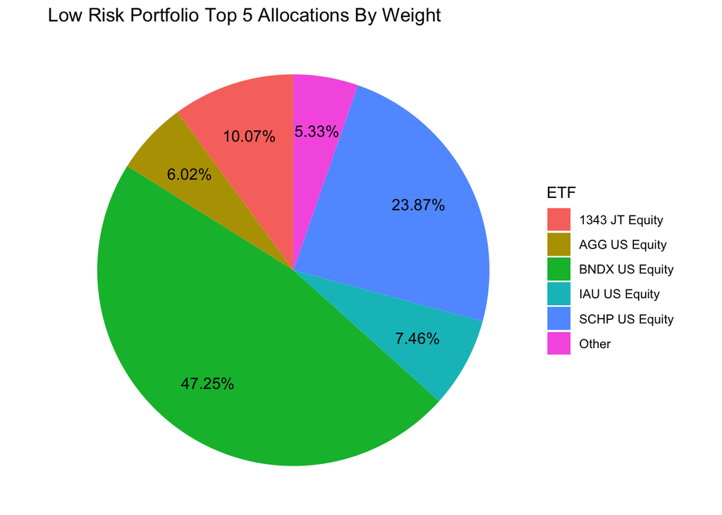

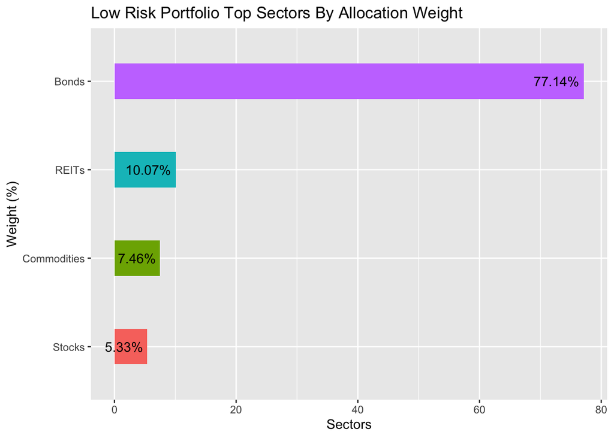

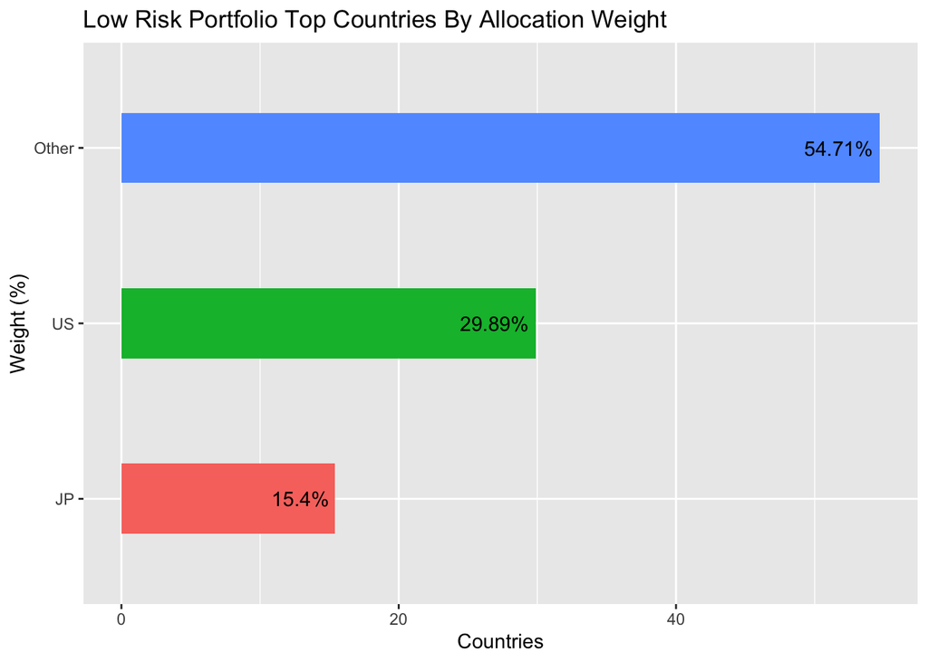

### Medium Risk Portfolio

> The aim for the medium risk portfolio is to generate a higher return by taking on a reasonable level of risk; balancing return on risk. The *tangent portfolio* was used to decide the weights of this portfolio.

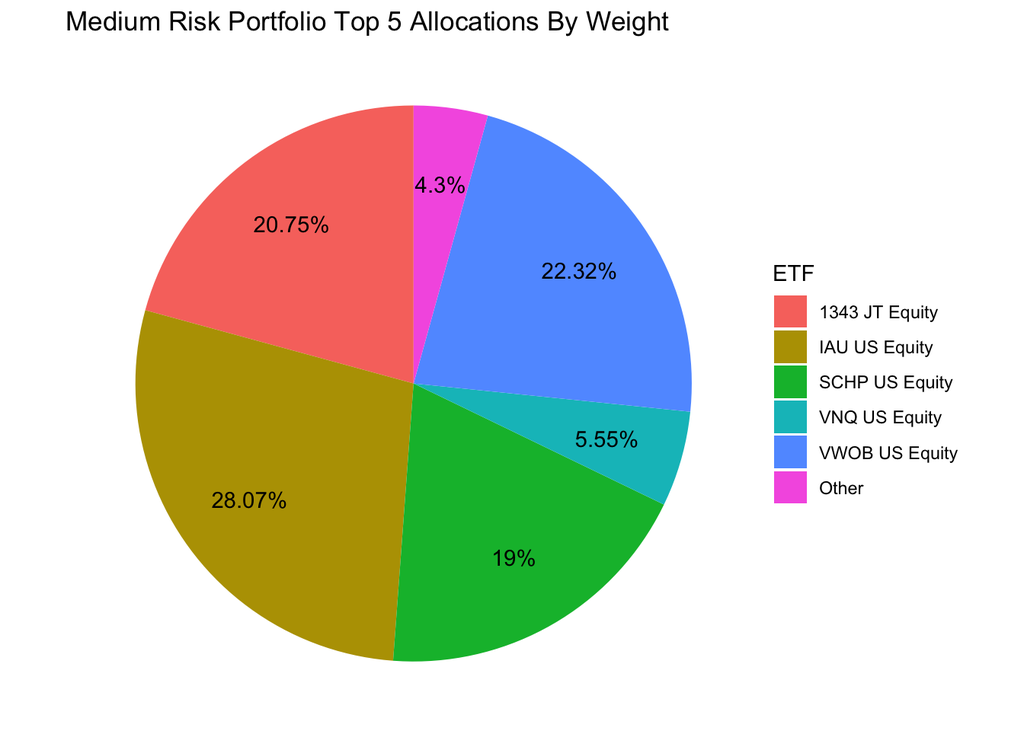

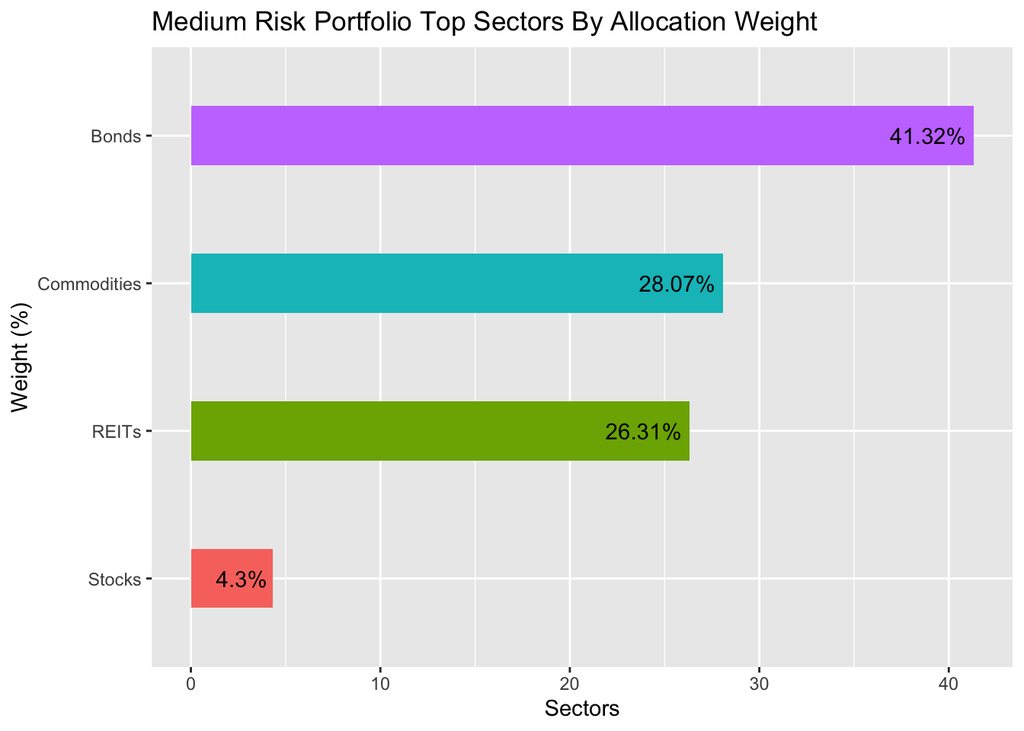

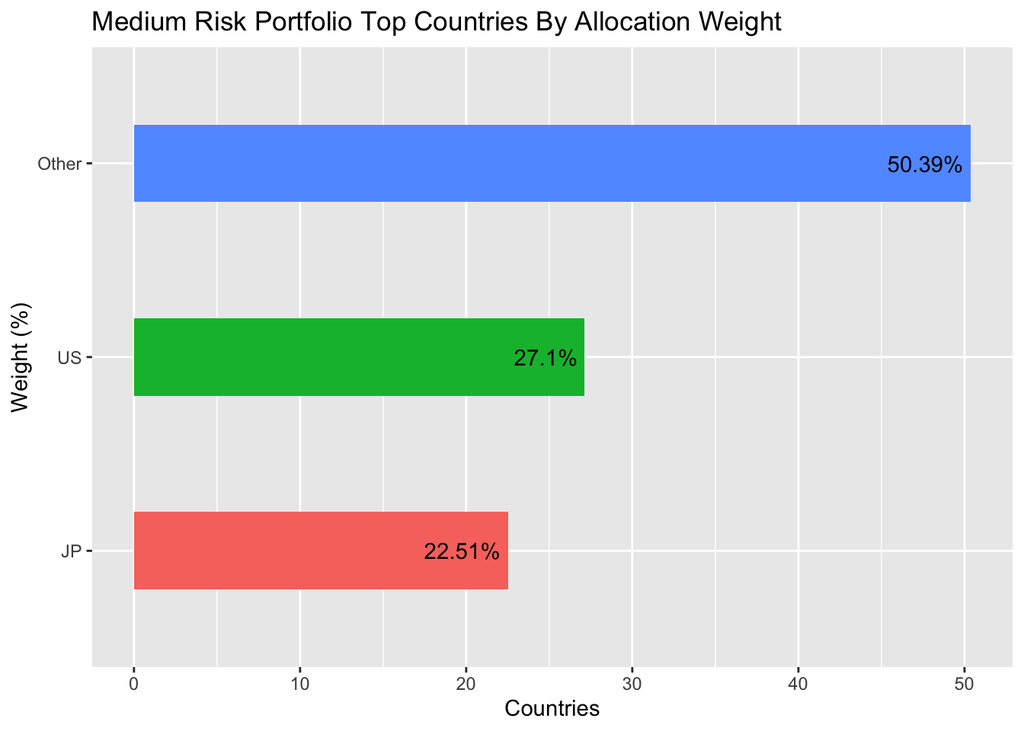

### High Risk Portfolio

> The aim for the high risk portfolio is to maximise returns. This can result in a higher level of risk, but greater returns are generated. For the weights of the portfolio, we decided to rebalance asset allocation. Bond ETFs have lower expected returns<sup>^</sup>, so we decided to not allocate to bond ETFs, and allocate more to riskier assets, in order to maximise returns while maintaining a decent Sharpe ratio.

**^: Expected returns of Bond ETFs in comparison to other sectors**

| sectors | Mean expected returns |
| --- | --- |
| Bonds | 0.0001904 |
| Commodities | 0.0004033 |
| REITs | 0.0004441 |
| Stocks | 0.0004271 |

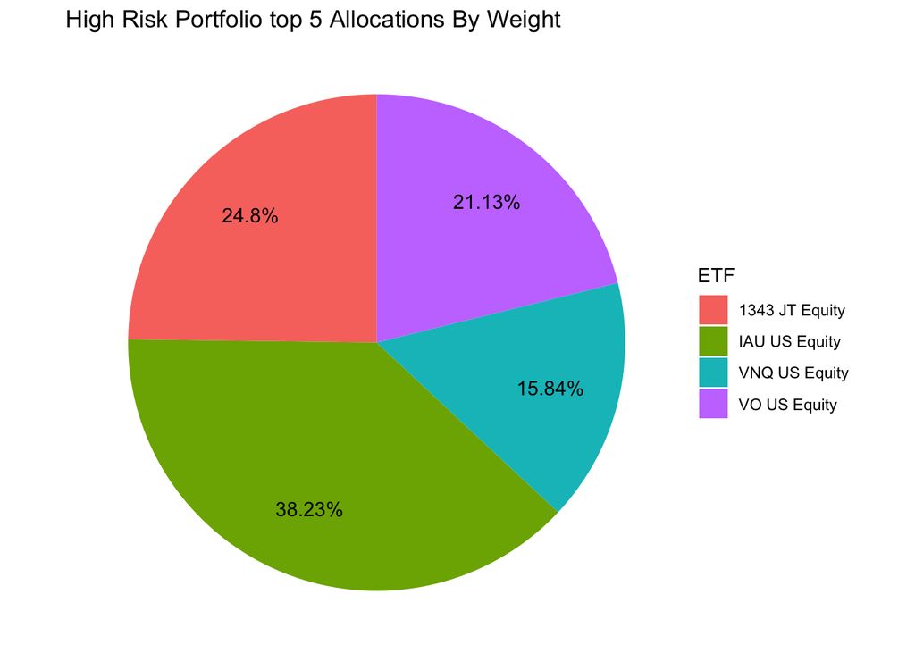

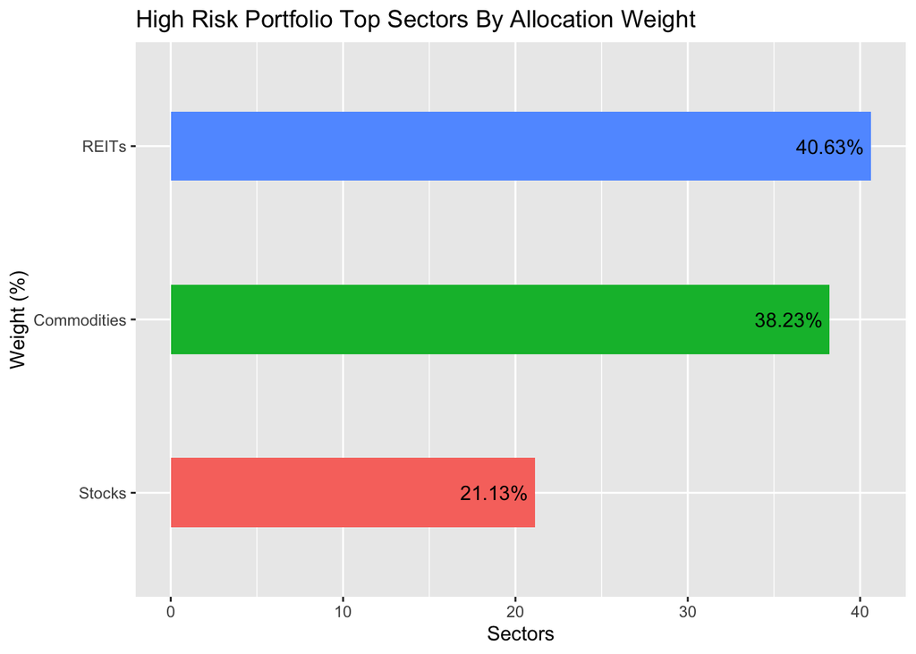

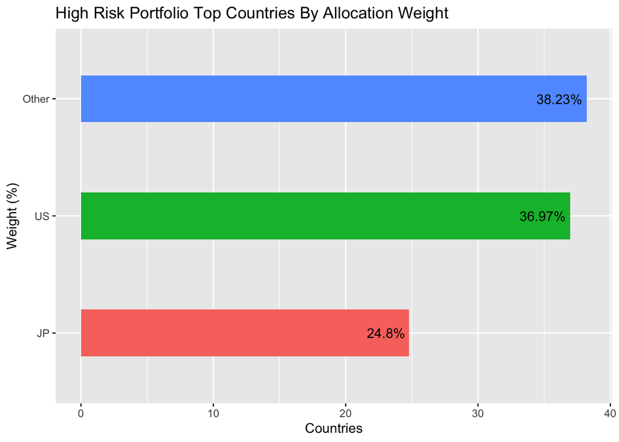

### Annualized Expected Returns

|  | CAPM | FF5F |
| --- | --- | --- |
| Min Variance Portfolio | 2.567925 | 1.515492 |
| Tangency Portfolio | 4.667354 | 3.108663 |
| Targeted Returns Portfolio | 8.372824 | 6.376264 |

### Portfolio Betas

|  | CAPM | FF5F |
| --- | --- | --- |
| Min Variance Portfolio | 0.3619246 | 0.1345795 |
| Tangency Portfolio | 0.6654168 | 0.2629902 |
| Targeted Returns Portfolio | 1.1865725 | 0.5362942 |

### Sharpe Ratio

|  | Sharpe Ratio |
| --- | --- |
| Min Variance Portfolio | 0.6808199 |
| Tangency Portfolio | 0.8730937 |
| Targeted Returns Portfolio | 0.8168123 |

### Backtesting Against Market

> Through backtesting on past data (2001 - 2022), the results are as shown:
> - Initial investment of 10,000 JPY
> - Market performance (38004.90 JPY)
> - High risk portfolio *outperforms* the market (65615.91 JPY)
> - Medium risk portfolio *outperforms* the market (49197.78 JPY)
> - Low risk portfolio *under-performs* the market (28613.10 JPY)

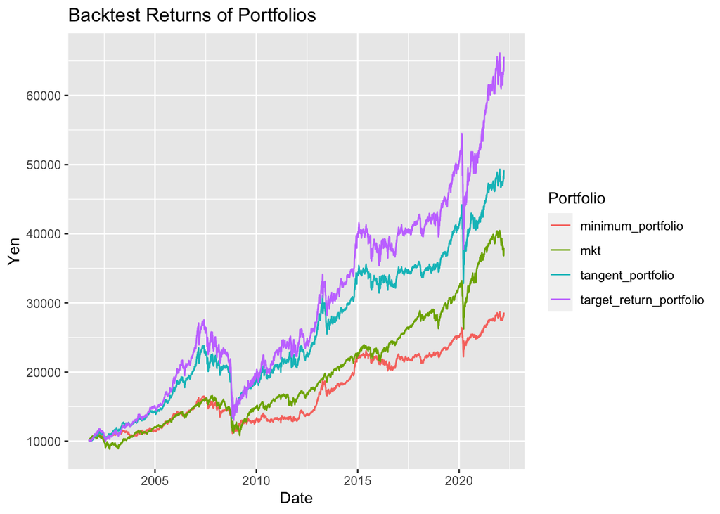

## Appendix

### FF5F Model

[figure not shown]

## Correlation Plot

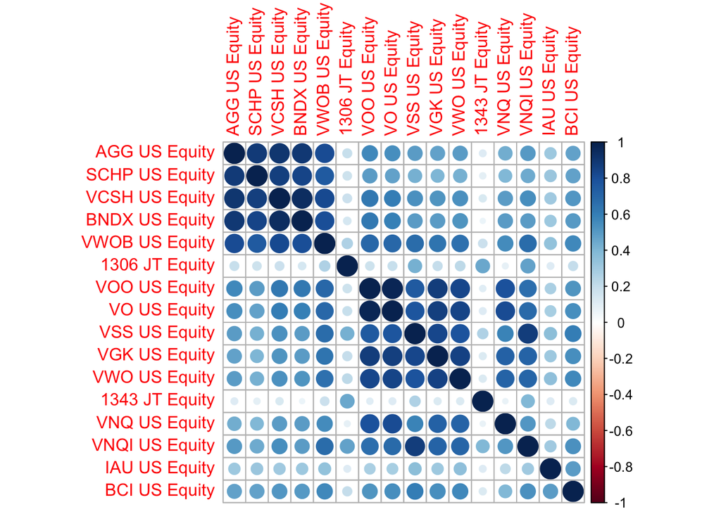

The correlation plot is used to visually identify the stocks that are highly correlated. One advantage of having low correlation between assets is a reduction of volatility of the portfolio.

Observations:

- All equities have a positive correlation with one another.
- Japanese Equities (1306.JT, 1343.JT) are weakly correlated to US equities.
- There are two distinct groups of equities that are strongly correlated.
  - Group 1:
    - AGG US Equity
    - SCHP US Equity
    - VCSH US Equity
    - BNDX US Equity
    - VWOB US Equity
  - Group 2:
    - VOO US Equity
    - VO US Equity
    - VSS US Equity
    - VGK US Equity
    - VWO US Equity
    - VNQ US Equity
    - VNQI US Equity

## Portfolio Correlation Plot

Low-Risk Portfolio

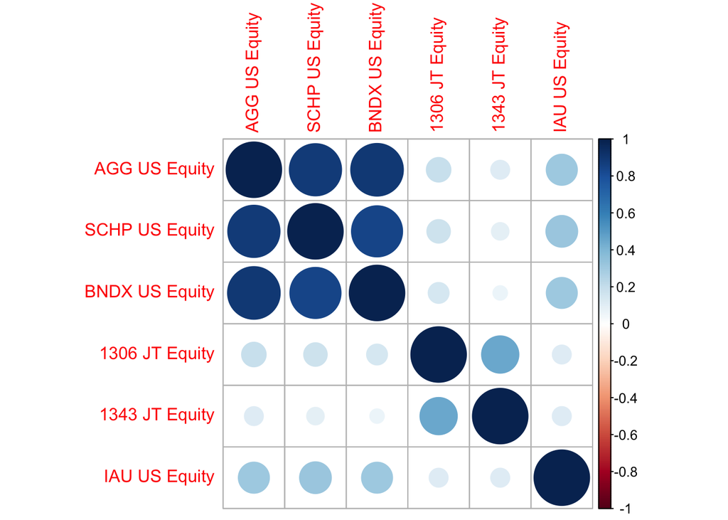

Medium-Risk Portfolio

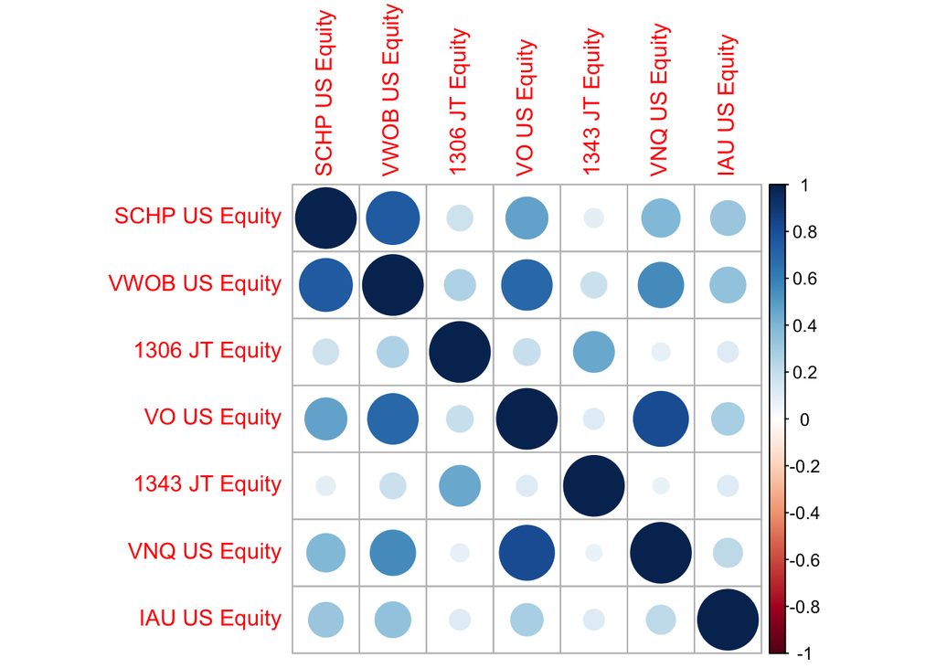

High-Risk Portfolio

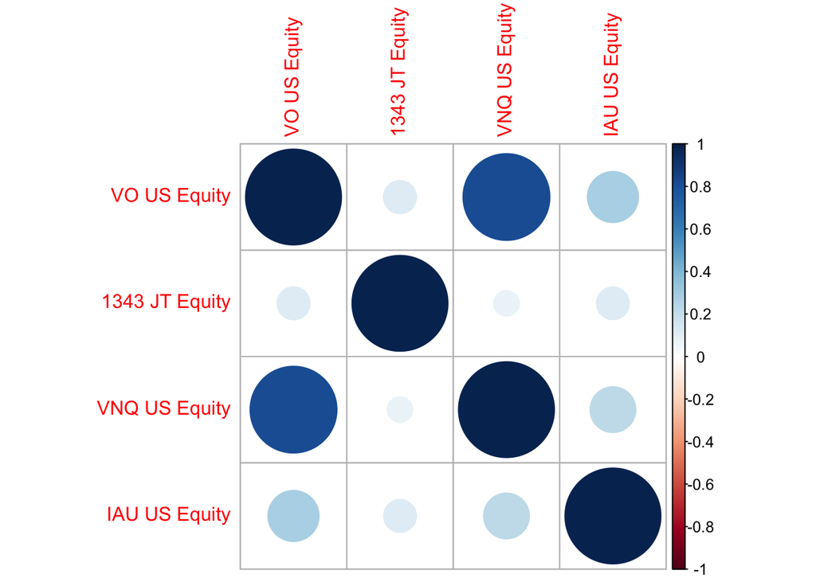

## CAPM Model

CAPM regression equation

$$E(R_{i}^{*})=\alpha_{i}+\beta_{i}E(R_{m}^{*})+E(\epsilon_{i})$$

|  | alpha | p-value | beta | SD(error) | mu |
| --- | --- | --- | --- | --- | --- |
| AGG US Equity | 0.0000688 | 0.3680336 | 0.3286462 | 0.0055803 | 0.0000857 |
| SCHP US Equity | 0.0001298 | 0.0983686 | 0.2676900 | 0.0057320 | 0.0000698 |
| VCSH US Equity | 0.0000591 | 0.4310422 | 0.3320302 | 0.0054791 | 0.0000866 |
| BNDX US Equity | 0.0000756 | 0.3179416 | 0.2971913 | 0.0055217 | 0.0000775 |
| VWOB US Equity | 0.0001071 | 0.2308821 | 0.7524220 | 0.0065239 | 0.0001963 |
| X1306 JT Equity | 0.0000254 | 0.8768549 | 0.9069314 | 0.0119469 | 0.0002366 |
| VOO US Equity | -0.0001430 | 0.1954112 | 2.2846024 | 0.0080626 | 0.0005959 |
| VO US Equity | -0.0001067 | 0.3630876 | 2.4104556 | 0.0085596 | 0.0006287 |
| VSS US Equity | -0.0000840 | 0.4491948 | 1.8756463 | 0.0081038 | 0.0004892 |
| VGK US Equity | -0.0002932 | 0.0225886 | 2.4936897 | 0.0093839 | 0.0006504 |
| VWO US Equity | -0.0001442 | 0.3788319 | 2.6050769 | 0.0119571 | 0.0006795 |
| X1343 JT Equity | 0.0002219 | 0.1980161 | 0.5679806 | 0.0125809 | 0.0001481 |
| VNQ US Equity | -0.0000373 | 0.8558592 | 2.3422793 | 0.0149880 | 0.0006109 |
| VNQI US Equity | -0.0000633 | 0.6078273 | 1.6794573 | 0.0090026 | 0.0004381 |
| IAU US Equity | 0.0002858 | 0.0502915 | 0.4325701 | 0.0106568 | 0.0001128 |
| BCI US Equity | -0.0000931 | 0.5323993 | 0.9633329 | 0.0108871 | 0.0002513 |

Since the p-value for all equities are greater than the level of significance (0.01), we conclude that the alphas are not statistically different from 0, and hence the alpha values are statistically insignificant

Given that the alpha value is statistically insignificant and $E(\epsilon_{i})=0$, the unconditional expected returns can now be calculated using $\beta_{i}E(R_{m}^{*})$.

## FF5F Model

FF5F Equation

$$E(R_{i}^{*})=\alpha_{i}+\beta_{i}E(R_{m}^{*})+s_{i}E(SMB) + h_{i}E(HML) + r_{i}E(RMW) + c_{i}E(CMA) +E(\epsilon_{i})$$

|  | alpha | beta | si | hi | ri | ci | alpha’s p-value |
| --- | --- | --- | --- | --- | --- | --- | --- |
| AGG US Equity | 0.0001083 | 0.1328630 | -0.0489490 | 0.0503769 | 0.0516906 | -0.0967164 | 0.1744306 |
| SCHP US Equity | 0.0001592 | 0.1027816 | -0.0097840 | 0.0518738 | 0.0642711 | -0.1189161 | 0.0509341 |
| VCSH US Equity | 0.0000855 | 0.1473371 | -0.0152034 | 0.0640815 | 0.0659479 | -0.0807989 | 0.2697461 |
| BNDX US Equity | 0.0000934 | 0.1448910 | -0.0242558 | 0.0430370 | 0.0567812 | -0.0615970 | 0.2287096 |
| VWOB US Equity | 0.0001902 | 0.3009293 | -0.0294093 | 0.1055489 | 0.0731724 | -0.1369375 | 0.0467431 |
| X1306 JT Equity | 0.0002015 | 0.1331880 | -0.0485961 | 0.0705099 | -0.1212111 | -0.0900096 | 0.2616999 |
| VOO US Equity | -0.0000067 | 1.1642397 | -0.1614678 | 0.0949735 | 0.0989256 | -0.0167871 | 0.9338339 |
| VO US Equity | 0.0000422 | 1.1768641 | 0.1858568 | 0.1092089 | 0.0321480 | -0.0893080 | 0.6321428 |
| VSS US Equity | 0.0001127 | 0.7272038 | 0.0797552 | 0.1724921 | -0.0601377 | -0.0926550 | 0.3913682 |
| VGK US Equity | -0.0000981 | 1.1157617 | -0.0567171 | 0.2672902 | 0.0534768 | -0.0126940 | 0.4576234 |
| VWO US Equity | 0.0000555 | 1.1887586 | 0.0083056 | 0.1999906 | 0.1005986 | -0.2102639 | 0.7381249 |
| X1343 JT Equity | 0.0002707 | 0.1148036 | -0.0276909 | -0.0123536 | 0.0463546 | -0.0002508 | 0.1372305 |
| VNQ US Equity | 0.0000670 | 1.1530994 | 0.2688263 | 0.6116935 | 0.2492444 | -0.2537163 | 0.7013570 |
| VNQI US Equity | 0.0001169 | 0.6054554 | 0.0380108 | 0.1343183 | 0.0083211 | -0.1572875 | 0.4286640 |
| IAU US Equity | 0.0003076 | 0.2001031 | 0.0496449 | -0.0710191 | 0.1357049 | 0.0405429 | 0.0425326 |
| BCI US Equity | -0.0000195 | 0.3837715 | 0.0733948 | 0.1934314 | 0.1031124 | -0.2195502 | 0.8997623 |

Since the p-value for all equities are greater than the level of significance (0.01), we conclude that the alphas are not statistically different from 0, and hence the alpha values are statistically insignificant

Given that the alpha value is statistically insignificant and $E(\epsilon_{i})=0$, the unconditional expected returns can now be calculated using $\beta_{i}E(R_{m}^{*})+s_{i}E(SMB) + h_{i}E(HML) + r_{i}E(RMW) + c_{i}E(CMA)$.